# Web_scraping_project

```python
import requests
```

```python
from bs4 import BeautifulSoup as bs
```

```python
import pandas as pd
```

## 1. Importing Libraries 📦

The project begins by importing essential Python libraries for web scraping and data manipulation:

requests: Used to make HTTP requests to the Cricbuzz website to retrieve the HTML content of the ranking pages.

BeautifulSoup (bs): A library for parsing HTML and XML documents. It's used to navigate the HTML structure and find specific data points like player names, teams, and ratings.

pandas: An indispensable library for data analysis. It's used to store the scraped data in DataFrames, which are then used for cleaning, combining, and analyzing the data.

## 2. Data Extraction (Web Scraping) 🕸️

The core of the project involves scraping data from the following three URLs, which contain the ICC rankings for men's batting, bowling, and all-rounders:

https://www.cricbuzz.com/cricket-stats/icc-rankings/men/batting

https://www.cricbuzz.com/cricket-stats/icc-rankings/men/bowling

https://www.cricbuzz.com/cricket-stats/icc-rankings/men/all-rounder

The process for each category is as follows:

Making a request: The requests.get() function is used to fetch the HTML content of the specified URL. A successful request returns a Response [200], indicating a successful connection.

Parsing the HTML: BeautifulSoup is then used to parse the raw HTML text, making it easy to search for specific elements.

Finding data: CSS selectors like class_="text-hvr-underline text-bold cb-font-16" are used to locate HTML tags containing player names, teams, ratings, and positions.

Storing in a list of dictionaries: The scraped data is stored in lists of dictionaries, with each dictionary representing a single data point (e.g., {"Player": "Joe Root"}).

Creating pandas DataFrames: The lists are then converted into pandas DataFrames, providing a tabular structure for the data.

```python
url1="https://www.cricbuzz.com/cricket-stats/icc-rankings/men/batting"
```

```python
respond=requests.get(url1)
```

```python
respond
```

```
<Response [200]>
```

```python
soup=bs(respond.text,"html.parser")
```

```python
soup
```

[output not shown]

```python
player=soup.find_all("a",class_="text-hvr-underline text-bold cb-font-16")
```

```python
player
```

[output not shown]

```python
for i in player:
    print(i.text)
```

```
Joe Root
Harry Brook
Kane Williamson
Steven Smith
Yashasvi Jaiswal
Temba Bavuma
Kamindu Mendis
Rishabh Pant
Daryl Mitchell
Ben Duckett
Travis Head
Saud Shakeel
Shubman Gill
Dinesh Chandimal
Aiden Markram
Shubman Gill
Rohit Sharma
Babar Azam
Virat Kohli
Daryl Mitchell
Charith Asalanka
Harry Tector
Shreyas Iyer
Shai Hope
Ibrahim Zadran
Travis Head
Kusal Mendis
Pathum Nissanka
Keacy Carty
KL Rahul
Abhishek Sharma
Tilak Varma
Philip Salt
Jos Buttler
Travis Head
Suryakumar Yadav
Pathum Nissanka
Tim Seifert
Kusal Perera
Tim David
Yashasvi Jaiswal
Josh Inglis
Shai Hope
Reeza Hendricks
```

```python
all_Players=[{"Player":i.text} for i in player]
```

```python
df=pd.DataFrame(all_Players)
```

```python
df["Player"]=df["Player"].str.strip()
```

```python
Team=soup.find_all("div",class_="cb-font-12 text-gray")
```

```python
all_Teams=[{"Team":i.text} for i in Team]
```

```python
df1=pd.DataFrame(all_Teams)
```

```python
df1
```

|  | Team |
| --- | --- |
| 0 | ENGLAND |
| 1 | ENGLAND |
| 2 | NEW ZEALAND |
| 3 | AUSTRALIA |
| 4 | INDIA |
| 5 | SOUTH AFRICA |
| 6 | SRI LANKA |
| 7 | INDIA |
| 8 | NEW ZEALAND |
| 9 | ENGLAND |
| 10 | AUSTRALIA |
| 11 | PAKISTAN |
| 12 | INDIA |
| 13 | SRI LANKA |
| 14 | SOUTH AFRICA |
| 15 | INDIA |
| 16 | INDIA |
| 17 | PAKISTAN |
| 18 | INDIA |
| 19 | NEW ZEALAND |
| 20 | SRI LANKA |
| 21 | IRELAND |
| 22 | INDIA |
| 23 | WEST INDIES |
| 24 | AFGHANISTAN |
| 25 | AUSTRALIA |
| 26 | SRI LANKA |
| 27 | SRI LANKA |
| 28 | WEST INDIES |
| 29 | INDIA |
| 30 | INDIA |
| 31 | INDIA |
| 32 | ENGLAND |
| 33 | ENGLAND |
| 34 | AUSTRALIA |
| 35 | INDIA |
| 36 | SRI LANKA |
| 37 | NEW ZEALAND |
| 38 | SRI LANKA |
| 39 | AUSTRALIA |
| 40 | INDIA |
| 41 | AUSTRALIA |
| 42 | WEST INDIES |
| 43 | SOUTH AFRICA |

```python
import pandas as pd
```

```python
combined_df = pd.concat([df, df1], axis=1)
```

```python
combined_df
```

|  | Player | Team |
| --- | --- | --- |
| 0 | Joe Root | ENGLAND |
| 1 | Harry Brook | ENGLAND |
| 2 | Kane Williamson | NEW ZEALAND |
| 3 | Steven Smith | AUSTRALIA |
| 4 | Yashasvi Jaiswal | INDIA |
| 5 | Temba Bavuma | SOUTH AFRICA |
| 6 | Kamindu Mendis | SRI LANKA |
| 7 | Rishabh Pant | INDIA |
| 8 | Daryl Mitchell | NEW ZEALAND |
| 9 | Ben Duckett | ENGLAND |
| 10 | Travis Head | AUSTRALIA |
| 11 | Saud Shakeel | PAKISTAN |
| 12 | Shubman Gill | INDIA |
| 13 | Dinesh Chandimal | SRI LANKA |
| 14 | Aiden Markram | SOUTH AFRICA |
| 15 | Shubman Gill | INDIA |
| 16 | Rohit Sharma | INDIA |
| 17 | Babar Azam | PAKISTAN |
| 18 | Virat Kohli | INDIA |
| 19 | Daryl Mitchell | NEW ZEALAND |
| 20 | Charith Asalanka | SRI LANKA |
| 21 | Harry Tector | IRELAND |
| 22 | Shreyas Iyer | INDIA |
| 23 | Shai Hope | WEST INDIES |
| 24 | Ibrahim Zadran | AFGHANISTAN |
| 25 | Travis Head | AUSTRALIA |
| 26 | Kusal Mendis | SRI LANKA |
| 27 | Pathum Nissanka | SRI LANKA |
| 28 | Keacy Carty | WEST INDIES |
| 29 | KL Rahul | INDIA |
| 30 | Abhishek Sharma | INDIA |
| 31 | Tilak Varma | INDIA |
| 32 | Philip Salt | ENGLAND |
| 33 | Jos Buttler | ENGLAND |
| 34 | Travis Head | AUSTRALIA |
| 35 | Suryakumar Yadav | INDIA |
| 36 | Pathum Nissanka | SRI LANKA |
| 37 | Tim Seifert | NEW ZEALAND |
| 38 | Kusal Perera | SRI LANKA |
| 39 | Tim David | AUSTRALIA |
| 40 | Yashasvi Jaiswal | INDIA |
| 41 | Josh Inglis | AUSTRALIA |
| 42 | Shai Hope | WEST INDIES |
| 43 | Reeza Hendricks | SOUTH AFRICA |

```python
Rating=soup.find_all("div",class_="cb-col cb-col-17 cb-rank-tbl pull-right")
```

```python
all_rating=[{"Rating":i.text} for i in Rating]
```

```python
df2=pd.DataFrame(all_rating)
```

```python
combined=pd.concat([combined_df,df2],axis=1)
```

```python
Position=soup.find_all("div",class_="cb-col cb-col-16 cb-rank-tbl cb-font-16")
all_rat=[{"Position":i.text} for i in Position]
df3=pd.DataFrame(all_rat)
combined=pd.concat([combined,df3],axis=1)
```

```python
combined["Role"]="Batsman"
```

```python
df['Format'] = ''

combined.loc[0:14, 'Format'] = 'Test'
combined.loc[15:29, 'Format'] = 'ODI'
combined.loc[30:43, 'Format'] = 'T20'


print(combined)
```

```
              Player          Team Rating Position     Role Format
0           Joe Root       ENGLAND    908        1  Batsman   Test
1        Harry Brook       ENGLAND    868        2  Batsman   Test
2    Kane Williamson   NEW ZEALAND    850        3  Batsman   Test
3       Steven Smith     AUSTRALIA    816        4  Batsman   Test
4   Yashasvi Jaiswal         INDIA    792        5  Batsman   Test
5       Temba Bavuma  SOUTH AFRICA    790        6  Batsman   Test
6     Kamindu Mendis     SRI LANKA    781        7  Batsman   Test
7       Rishabh Pant         INDIA    768        8  Batsman   Test
8     Daryl Mitchell   NEW ZEALAND    748        9  Batsman   Test
9        Ben Duckett       ENGLAND    747       10  Batsman   Test
10       Travis Head     AUSTRALIA    740       11  Batsman   Test
11      Saud Shakeel      PAKISTAN    739       12  Batsman   Test
12      Shubman Gill         INDIA    725       13  Batsman   Test
13  Dinesh Chandimal     SRI LANKA    717       14  Batsman   Test
```

[output cut: 30 more lines]

```python
combined = combined.sort_values(by='Position',ignore_index=True)
```

```python
bowler_url="https://www.cricbuzz.com/cricket-stats/icc-rankings/men/bowling"
b_res=requests.get(bowler_url)
print(b_res)
```

```
<Response [200]>
```

```python
b_soup=bs(b_res.text,"html.parser")
```

```python
bowler=b_soup.find_all("a",class_="text-hvr-underline text-bold cb-font-16")
all_bowlers=[{"Player":i.text} for i in bowler]
df5=pd.DataFrame(all_bowlers)
```

```python
teams=b_soup.find_all("div",class_="cb-font-12 text-gray")
all_bowlers=[{"Team":i.text} for i in teams]
df6=pd.DataFrame(all_bowlers)
```

```python
ratings=b_soup.find_all("div",class_="cb-col cb-col-17 cb-rank-tbl pull-right")
all_bowlers=[{"Rating":i.text} for i in ratings]
df7=pd.DataFrame(all_bowlers)
```

```python
combined2=pd.concat([df5,df6,df7],axis=1)
```

```python
combined2["Role"]="Bowler"
```

```python
position=b_soup.find_all("div",class_="cb-col cb-col-16 cb-rank-tbl cb-font-16")
all_bs=[{"Position":i.text} for i in position]
df8=pd.DataFrame(all_bs)
```

```python
combined2=pd.concat([combined2,df8],axis=1)
```

```python
df['Format'] = ''
combined2.loc[0:14, 'Format'] = 'Test'
combined2.loc[15:29, 'Format'] = 'ODI'
combined2.loc[30:44, 'Format'] = 'T20'
combined2
```

|  | Player | Team | Rating | Role | Position | Format |
| --- | --- | --- | --- | --- | --- | --- |
| 0 | Jasprit Bumrah | INDIA | 889 | Bowler | 1 | Test |
| 1 | Kagiso Rabada | SOUTH AFRICA | 851 | Bowler | 2 | Test |
| 2 | Matt Henry | NEW ZEALAND | 846 | Bowler | 3 | Test |
| 3 | Pat Cummins | AUSTRALIA | 838 | Bowler | 4 | Test |
| 4 | Josh Hazlewood | AUSTRALIA | 815 | Bowler | 5 | Test |
| 5 | Noman Ali | PAKISTAN | 806 | Bowler | 6 | Test |
| 6 | Scott Boland | AUSTRALIA | 784 | Bowler | 7 | Test |
| 7 | Nathan Lyon | AUSTRALIA | 769 | Bowler | 8 | Test |
| 8 | Marco Jansen | SOUTH AFRICA | 767 | Bowler | 9 | Test |
| 9 | Mitchell Starc | AUSTRALIA | 766 | Bowler | 10 | Test |
| 10 | Gus Atkinson | ENGLAND | 766 | Bowler | 10 | Test |
| 11 | Jayden Seales | WEST INDIES | 722 | Bowler | 12 | Test |
| 12 | Prabath Jayasuriya | SRI LANKA | 693 | Bowler | 13 | Test |
| 13 | Shamar Joseph | WEST INDIES | 681 | Bowler | 14 | Test |
| 14 | Mohammed Siraj | INDIA | 674 | Bowler | 15 | Test |
| 15 | Keshav Maharaj | SOUTH AFRICA | 680 | Bowler | 1 | ODI |
| 16 | Maheesh Theekshana | SRI LANKA | 659 | Bowler | 2 | ODI |
| 17 | Jofra Archer | ENGLAND | 654 | Bowler | 3 | ODI |
| 18 | Kuldeep Yadav | INDIA | 650 | Bowler | 4 | ODI |
| 19 | Bernard Scholtz | NAMIBIA | 645 | Bowler | 5 | ODI |
| 20 | Rashid Khan | AFGHANISTAN | 640 | Bowler | 6 | ODI |
| 21 | Mitchell Santner | NEW ZEALAND | 637 | Bowler | 7 | ODI |
| 22 | Adil Rashid | ENGLAND | 628 | Bowler | 8 | ODI |
| 23 | Matt Henry | NEW ZEALAND | 622 | Bowler | 9 | ODI |
| 24 | Ravindra Jadeja | INDIA | 616 | Bowler | 10 | ODI |
| 25 | Wanindu Hasaranga | SRI LANKA | 607 | Bowler | 11 | ODI |
| 26 | Gudakesh Motie | WEST INDIES | 605 | Bowler | 12 | ODI |
| 27 | Adam Zampa | AUSTRALIA | 603 | Bowler | 13 | ODI |
| 28 | Mohammed Shami | INDIA | 596 | Bowler | 14 | ODI |
| 29 | Shaheen Afridi | PAKISTAN | 593 | Bowler | 15 | ODI |
| 30 | Jacob Duffy | NEW ZEALAND | 717 | Bowler | 1 | T20 |
| 31 | Adil Rashid | ENGLAND | 710 | Bowler | 2 | T20 |
| 32 | Akeal Hosein | WEST INDIES | 707 | Bowler | 3 | T20 |
| 33 | Varun Chakaravarthy | INDIA | 706 | Bowler | 4 | T20 |
| 34 | Adam Zampa | AUSTRALIA | 700 | Bowler | 5 | T20 |
| 35 | Ravi Bishnoi | INDIA | 674 | Bowler | 6 | T20 |
| 36 | Wanindu Hasaranga | SRI LANKA | 659 | Bowler | 7 | T20 |
| 37 | Nathan Ellis | AUSTRALIA | 658 | Bowler | 8 | T20 |
| 38 | Arshdeep Singh | INDIA | 653 | Bowler | 9 | T20 |
| 39 | Rashid Khan | AFGHANISTAN | 653 | Bowler | 9 | T20 |
| 40 | Mustafizur Rahman | BANGLADESH | 641 | Bowler | 11 | T20 |
| 41 | Nuwan Thushara | SRI LANKA | 637 | Bowler | 12 | T20 |
| 42 | Axar Patel | INDIA | 636 | Bowler | 13 | T20 |
| 43 | Maheesh Theekshana | SRI LANKA | 635 | Bowler | 14 | T20 |
| 44 | Sufiyan Muqeem | PAKISTAN | 632 | Bowler | 15 | T20 |

```python
combined
```

|  | Player | Team | Rating | Position | Role | Format |
| --- | --- | --- | --- | --- | --- | --- |
| 0 | Joe Root | ENGLAND | 908 | 1 | Batsman | Test |
| 1 | Shubman Gill | INDIA | 784 | 1 | Batsman | ODI |
| 2 | Abhishek Sharma | INDIA | 829 | 1 | Batsman | T20 |
| 3 | Tim David | AUSTRALIA | 676 | 10 | Batsman | T20 |
| 4 | Ibrahim Zadran | AFGHANISTAN | 676 | 10 | Batsman | ODI |
| 5 | Ben Duckett | ENGLAND | 747 | 10 | Batsman | Test |
| 6 | Yashasvi Jaiswal | INDIA | 673 | 11 | Batsman | T20 |
| 7 | Travis Head | AUSTRALIA | 669 | 11 | Batsman | ODI |
| 8 | Travis Head | AUSTRALIA | 740 | 11 | Batsman | Test |
| 9 | Saud Shakeel | PAKISTAN | 739 | 12 | Batsman | Test |
| 10 | Kusal Mendis | SRI LANKA | 656 | 12 | Batsman | ODI |
| 11 | Josh Inglis | AUSTRALIA | 671 | 12 | Batsman | T20 |
| 12 | Shubman Gill | INDIA | 725 | 13 | Batsman | Test |
| 13 | Pathum Nissanka | SRI LANKA | 654 | 13 | Batsman | ODI |
| 14 | Keacy Carty | WEST INDIES | 642 | 14 | Batsman | ODI |
| 15 | Dinesh Chandimal | SRI LANKA | 717 | 14 | Batsman | Test |
| 16 | Shai Hope | WEST INDIES | 652 | 14 | Batsman | T20 |
| 17 | KL Rahul | INDIA | 638 | 15 | Batsman | ODI |
| 18 | Reeza Hendricks | SOUTH AFRICA | 647 | 15 | Batsman | T20 |
| 19 | Aiden Markram | SOUTH AFRICA | 709 | 15 | Batsman | Test |
| 20 | Tilak Varma | INDIA | 804 | 2 | Batsman | T20 |
| 21 | Harry Brook | ENGLAND | 868 | 2 | Batsman | Test |
| 22 | Rohit Sharma | INDIA | 756 | 2 | Batsman | ODI |
| 23 | Babar Azam | PAKISTAN | 739 | 3 | Batsman | ODI |
| 24 | Kane Williamson | NEW ZEALAND | 850 | 3 | Batsman | Test |
| 25 | Philip Salt | ENGLAND | 791 | 3 | Batsman | T20 |
| 26 | Steven Smith | AUSTRALIA | 816 | 4 | Batsman | Test |
| 27 | Jos Buttler | ENGLAND | 772 | 4 | Batsman | T20 |
| 28 | Virat Kohli | INDIA | 736 | 4 | Batsman | ODI |
| 29 | Travis Head | AUSTRALIA | 771 | 5 | Batsman | T20 |
| 30 | Daryl Mitchell | NEW ZEALAND | 720 | 5 | Batsman | ODI |
| 31 | Yashasvi Jaiswal | INDIA | 792 | 5 | Batsman | Test |
| 32 | Temba Bavuma | SOUTH AFRICA | 790 | 6 | Batsman | Test |
| 33 | Suryakumar Yadav | INDIA | 739 | 6 | Batsman | T20 |
| 34 | Charith Asalanka | SRI LANKA | 716 | 6 | Batsman | ODI |
| 35 | Kamindu Mendis | SRI LANKA | 781 | 7 | Batsman | Test |
| 36 | Pathum Nissanka | SRI LANKA | 730 | 7 | Batsman | T20 |
| 37 | Harry Tector | IRELAND | 708 | 7 | Batsman | ODI |
| 38 | Rishabh Pant | INDIA | 768 | 8 | Batsman | Test |
| 39 | Tim Seifert | NEW ZEALAND | 725 | 8 | Batsman | T20 |
| 40 | Shreyas Iyer | INDIA | 704 | 8 | Batsman | ODI |
| 41 | Daryl Mitchell | NEW ZEALAND | 748 | 9 | Batsman | Test |
| 42 | Kusal Perera | SRI LANKA | 687 | 9 | Batsman | T20 |
| 43 | Shai Hope | WEST INDIES | 699 | 9 | Batsman | ODI |

```python
combined2 = combined2.sort_values(by='Position',ignore_index=True)
```

```python
Ranking = pd.concat([combined, combined2], ignore_index=True)
```

```python
Ranking
```

|  | Player | Team | Rating | Position | Role | Format |
| --- | --- | --- | --- | --- | --- | --- |
| 0 | Joe Root | ENGLAND | 908 | 1 | Batsman | Test |
| 1 | Shubman Gill | INDIA | 784 | 1 | Batsman | ODI |
| 2 | Abhishek Sharma | INDIA | 829 | 1 | Batsman | T20 |
| 3 | Tim David | AUSTRALIA | 676 | 10 | Batsman | T20 |
| 4 | Ibrahim Zadran | AFGHANISTAN | 676 | 10 | Batsman | ODI |
| ... | ... | ... | ... | ... | ... | ... |
| 84 | Adil Rashid | ENGLAND | 628 | 8 | Bowler | ODI |
| 85 | Marco Jansen | SOUTH AFRICA | 767 | 9 | Bowler | Test |
| 86 | Arshdeep Singh | INDIA | 653 | 9 | Bowler | T20 |
| 87 | Rashid Khan | AFGHANISTAN | 653 | 9 | Bowler | T20 |
| 88 | Matt Henry | NEW ZEALAND | 622 | 9 | Bowler | ODI |

89 rows × 6 columns

```python
all_url="https://www.cricbuzz.com/cricket-stats/icc-rankings/men/all-rounder"
all_res=requests.get(all_url)
print(all_res)
```

```
<Response [200]>
```

```python
all_soup=bs(all_res.text,"html.parser")
```

```python
all_r=all_soup.find_all("a",class_="text-hvr-underline text-bold cb-font-16")
all_allrounders=[{"Player":i.text} for i in all_r]
df10=pd.DataFrame(all_allrounders)
```

```python
teams=all_soup.find_all("div",class_="cb-font-12 text-gray")
all_bowlers=[{"Team":i.text} for i in teams]
df14=pd.DataFrame(all_bowlers)
```

```python
ratings=all_soup.find_all("div",class_="cb-col cb-col-17 cb-rank-tbl pull-right")
all_bowlers=[{"Rating":i.text} for i in ratings]
df12=pd.DataFrame(all_bowlers)
```

```python
position=all_soup.find_all("div",class_="cb-col cb-col-16 cb-rank-tbl cb-font-16")
all_bs=[{"Position":i.text} for i in position]
df13=pd.DataFrame(all_bs)
```

```python
combined3=pd.concat([df10,df14,df12,df13],axis=1)
```

```python
combined3["Role"]="All-Rounder"
```

```python
df['Format'] = ''
combined3.loc[0:14, 'Format'] = 'Test'
combined3.loc[15:29, 'Format'] = 'ODI'
combined3.loc[30:44, 'Format'] = 'T20'
print(combined3)
```

```
                  Player          Team Rating Position         Role Format
0        Ravindra Jadeja         INDIA    405        1  All-Rounder   Test
1     Mehidy Hasan Miraz    BANGLADESH    305        2  All-Rounder   Test
2             Ben Stokes       ENGLAND    295        3  All-Rounder   Test
3           Wiaan Mulder  SOUTH AFRICA    284        4  All-Rounder   Test
4            Pat Cummins     AUSTRALIA    270        5  All-Rounder   Test
5           Marco Jansen  SOUTH AFRICA    269        6  All-Rounder   Test
6         Mitchell Starc     AUSTRALIA    238        7  All-Rounder   Test
7               Joe Root       ENGLAND    237        8  All-Rounder   Test
8           Gus Atkinson       ENGLAND    236        9  All-Rounder   Test
9           Jason Holder   WEST INDIES    234       10  All-Rounder   Test
10      Mitchell Santner   NEW ZEALAND    225       11  All-Rounder   Test
11            Matt Henry   NEW ZEALAND    203       12  All-Rounder   Test
12         Shamar Joseph   WEST INDIES    196       13  All-Rounder   Test
13          Corbin Bosch  SOUTH AFRICA    191       14  All-Rounder   Test
```

[output cut: 31 more lines]

```python
combined3.sort_values("Position",ignore_index=True)
```

|  | Player | Team | Rating | Position | Role | Format |
| --- | --- | --- | --- | --- | --- | --- |
| 0 | Ravindra Jadeja | INDIA | 405 | 1 | All-Rounder | Test |
| 1 | Sikandar Raza | ZIMBABWE | 302 | 1 | All-Rounder | ODI |
| 2 | Hardik Pandya | INDIA | 252 | 1 | All-Rounder | T20 |
| 3 | Jason Holder | WEST INDIES | 234 | 10 | All-Rounder | Test |
| 4 | Rachin Ravindra | NEW ZEALAND | 216 | 10 | All-Rounder | ODI |
| 5 | Wanindu Hasaranga | SRI LANKA | 210 | 11 | All-Rounder | ODI |
| 6 | Aiden Markram | SOUTH AFRICA | 168 | 11 | All-Rounder | T20 |
| 7 | Mitchell Santner | NEW ZEALAND | 225 | 11 | All-Rounder | Test |
| 8 | Matt Henry | NEW ZEALAND | 203 | 12 | All-Rounder | Test |
| 9 | Glenn Maxwell | AUSTRALIA | 209 | 12 | All-Rounder | ODI |
| 10 | Gerhard Erasmus | NAMIBIA | 164 | 12 | All-Rounder | T20 |
| 11 | Shamar Joseph | WEST INDIES | 196 | 13 | All-Rounder | Test |
| 12 | Axar Patel | INDIA | 161 | 13 | All-Rounder | T20 |
| 13 | Gudakesh Motie | WEST INDIES | 207 | 13 | All-Rounder | ODI |
| 14 | Gerhard Erasmus | NAMIBIA | 204 | 14 | All-Rounder | ODI |
| 15 | Corbin Bosch | SOUTH AFRICA | 191 | 14 | All-Rounder | Test |
| 16 | Jason Holder | WEST INDIES | 160 | 14 | All-Rounder | T20 |
| 17 | Axar Patel | INDIA | 200 | 15 | All-Rounder | ODI |
| 18 | Glenn Maxwell | AUSTRALIA | 157 | 15 | All-Rounder | T20 |
| 19 | Kagiso Rabada | SOUTH AFRICA | 188 | 15 | All-Rounder | Test |
| 20 | Mohammad Nabi | AFGHANISTAN | 217 | 2 | All-Rounder | T20 |
| 21 | Mehidy Hasan Miraz | BANGLADESH | 305 | 2 | All-Rounder | Test |
| 22 | Azmatullah Omarzai | AFGHANISTAN | 296 | 2 | All-Rounder | ODI |
| 23 | Ben Stokes | ENGLAND | 295 | 3 | All-Rounder | Test |
| 24 | Mohammad Nabi | AFGHANISTAN | 292 | 3 | All-Rounder | ODI |
| 25 | Dipendra Singh Airee | NEPAL | 209 | 3 | All-Rounder | T20 |
| 26 | Wiaan Mulder | SOUTH AFRICA | 284 | 4 | All-Rounder | Test |
| 27 | Sikandar Raza | ZIMBABWE | 207 | 4 | All-Rounder | T20 |
| 28 | Mehidy Hasan Miraz | BANGLADESH | 249 | 4 | All-Rounder | ODI |
| 29 | Liam Livingstone | ENGLAND | 196 | 5 | All-Rounder | T20 |
| 30 | Roston Chase | WEST INDIES | 196 | 5 | All-Rounder | T20 |
| 31 | Michael Bracewell | NEW ZEALAND | 246 | 5 | All-Rounder | ODI |
| 32 | Pat Cummins | AUSTRALIA | 270 | 5 | All-Rounder | Test |
| 33 | Marco Jansen | SOUTH AFRICA | 269 | 6 | All-Rounder | Test |
| 34 | Rashid Khan | AFGHANISTAN | 238 | 6 | All-Rounder | ODI |
| 35 | Mitchell Santner | NEW ZEALAND | 238 | 6 | All-Rounder | ODI |
| 36 | Mitchell Starc | AUSTRALIA | 238 | 7 | All-Rounder | Test |
| 37 | Romario Shepherd | WEST INDIES | 183 | 7 | All-Rounder | T20 |
| 38 | Joe Root | ENGLAND | 237 | 8 | All-Rounder | Test |
| 39 | Wanindu Hasaranga | SRI LANKA | 181 | 8 | All-Rounder | T20 |
| 40 | Brandon McMullen | SCOTLAND | 228 | 8 | All-Rounder | ODI |
| 41 | Gus Atkinson | ENGLAND | 236 | 9 | All-Rounder | Test |
| 42 | Saim Ayub | PAKISTAN | 179 | 9 | All-Rounder | T20 |
| 43 | Marcus Stoinis | AUSTRALIA | 179 | 9 | All-Rounder | T20 |
| 44 | Ravindra Jadeja | INDIA | 220 | 9 | All-Rounder | ODI |

```python
Ranking = pd.concat([Ranking,combined3], ignore_index=True)
```

```python
Ranking
```

|  | Player | Team | Rating | Position | Role | Format |
| --- | --- | --- | --- | --- | --- | --- |
| 0 | Joe Root | ENGLAND | 908 | 1 | Batsman | Test |
| 1 | Shubman Gill | INDIA | 784 | 1 | Batsman | ODI |
| 2 | Abhishek Sharma | INDIA | 829 | 1 | Batsman | T20 |
| 3 | Tim David | AUSTRALIA | 676 | 10 | Batsman | T20 |
| 4 | Ibrahim Zadran | AFGHANISTAN | 676 | 10 | Batsman | ODI |
| ... | ... | ... | ... | ... | ... | ... |
| 129 | Aiden Markram | SOUTH AFRICA | 168 | 11 | All-Rounder | T20 |
| 130 | Gerhard Erasmus | NAMIBIA | 164 | 12 | All-Rounder | T20 |
| 131 | Axar Patel | INDIA | 161 | 13 | All-Rounder | T20 |
| 132 | Jason Holder | WEST INDIES | 160 | 14 | All-Rounder | T20 |
| 133 | Glenn Maxwell | AUSTRALIA | 157 | 15 | All-Rounder | T20 |

134 rows × 6 columns

```python
player_roles = ['batting', 'bowling', 'all-rounder']
base_url = "https://www.cricbuzz.com/cricket-stats/icc-rankings/women/"
for role in player_roles:
    url = f"{base_url}{role}"
    res = requests.get(url)
    soup = bs(res.text, "html.parser")
    players = soup.find_all("a",class_="text-hvr-underline text-bold cb-font-16")
    for player in players:
        player=[{"Player":i.text} for i in players]
```

```python
df16=pd.DataFrame(player)
```

```python
player_roles = ['batting', 'bowling', 'all-rounder']
base_url = "https://www.cricbuzz.com/cricket-stats/icc-rankings/women/"
for role in player_roles:
    url = f"{base_url}{role}"
    res = requests.get(url)
    soup = bs(res.text, "html.parser")
    players = soup.find_all("div",class_="cb-font-12 text-gray")
    for player in players:
        teams = soup.find_all("div",class_="cb-font-12 text-gray")
        team=[{"Team":i.text} for i in teams]
```

```python
df17=pd.DataFrame(team)
```

```python
player_roles = ['batting', 'bowling', 'all-rounder']
base_url = "https://www.cricbuzz.com/cricket-stats/icc-rankings/women/"
for role in player_roles:
    url = f"{base_url}{role}"
    res = requests.get(url)
    soup = bs(res.text, "html.parser")
    players = soup.find_all("div",class_="cb-col cb-col-17 cb-rank-tbl pull-right")
    for player in players:
        teams = soup.find_all("div",class_="cb-col cb-col-17 cb-rank-tbl pull-right")
        rating=[{"Rating":i.text} for i in teams]
```

```python
df18=pd.DataFrame(rating)
```

```python
player_roles = ['batting', 'bowling', 'all-rounder']
base_url = "https://www.cricbuzz.com/cricket-stats/icc-rankings/women/"
for role in player_roles:
    url = f"{base_url}{role}"
    res = requests.get(url)
    soup = bs(res.text, "html.parser")
    players = soup.find_all("div",class_="cb-col cb-col-16 cb-rank-tbl cb-font-16")
    for player in players:
        teams = soup.find_all("div",class_="cb-col cb-col-16 cb-rank-tbl cb-font-16")
        position=[{"Position":i.text} for i in teams]
```

```python
df19=pd.DataFrame(position)
```

```python
ranks=pd.concat([df16,df17,df18,df19],axis=1)
```

```python
ranks["Role"]="All-Rounder"
```

```python
ranks['Format'] = ''
ranks.loc[0:14, 'Format'] = 'ODI'
ranks.loc[15:29, 'Format'] = 'T20'

print(ranks)
```

```
                 Player          Team Rating Position         Role Format
0      Ashleigh Gardner     AUSTRALIA    470        1  All-Rounder    ODI
1       Hayley Matthews   WEST INDIES    420        2  All-Rounder    ODI
2        Marizanne Kapp  SOUTH AFRICA    404        3  All-Rounder    ODI
3         Deepti Sharma         INDIA    369        4  All-Rounder    ODI
4           Amelia Kerr   NEW ZEALAND    338        5  All-Rounder    ODI
5   Chamari Athapaththu     SRI LANKA    291        6  All-Rounder    ODI
6    Annabel Sutherland     AUSTRALIA    278        7  All-Rounder    ODI
7      Nat Sciver-Brunt       ENGLAND    270        8  All-Rounder    ODI
8         Sophie Devine   NEW ZEALAND    259        9  All-Rounder    ODI
9      Orla Prendergast       IRELAND    258       10  All-Rounder    ODI
10           Alana King     AUSTRALIA    234       11  All-Rounder    ODI
11          Chloe Tryon  SOUTH AFRICA    219       12  All-Rounder    ODI
12      Nadine de Klerk  SOUTH AFRICA    213       13  All-Rounder    ODI
13       Charlotte Dean       ENGLAND    210       14  All-Rounder    ODI
```

[output cut: 16 more lines]

```python
player_roles = ['batting',"bowling"]
base_url = "https://www.cricbuzz.com/cricket-stats/icc-rankings/women/"
for role in player_roles:
    url = f"{base_url}{role}"
    res = requests.get(url)
    soup = bs(res.text, "html.parser")
    players = soup.find_all("a",class_="text-hvr-underline text-bold cb-font-16")
    for player in players:
        teams = soup.find_all("a",class_="text-hvr-underline text-bold cb-font-16")
        player=[{"Position":i.text} for i in teams]
```

```python
player_roles = ["bowling"]
base_url = "https://www.cricbuzz.com/cricket-stats/icc-rankings/women/"
for role in player_roles:
    url = f"{base_url}{role}"
    res = requests.get(url)
    soup = bs(res.text, "html.parser")
    players = soup.find_all("a",class_="text-hvr-underline text-bold cb-font-16")
    for player in players:
        teams = soup.find_all("a",class_="text-hvr-underline text-bold cb-font-16")
        player=[{"Player":i.text} for i in teams]
```

```python
df20=pd.DataFrame(player)
```

```python
player_roles = ["bowling"]
base_url = "https://www.cricbuzz.com/cricket-stats/icc-rankings/women/"
for role in player_roles:
    url = f"{base_url}{role}"
    res = requests.get(url)
    soup = bs(res.text, "html.parser")
    players = soup.find_all("div",class_="cb-font-12 text-gray")
    for player in players:
        teams = soup.find_all("div",class_="cb-font-12 text-gray")
        team=[{"Team":i.text} for i in teams]
```

```python
df21=pd.DataFrame(team)
```

```python
player_roles = ["bowling"]
base_url = "https://www.cricbuzz.com/cricket-stats/icc-rankings/women/"
for role in player_roles:
    url = f"{base_url}{role}"
    res = requests.get(url)
    soup = bs(res.text, "html.parser")
    players = soup.find_all("div",class_="cb-col cb-col-17 cb-rank-tbl pull-right")
    for player in players:
        teams = soup.find_all("div",class_="cb-col cb-col-17 cb-rank-tbl pull-right")
        rating=[{"Rating":i.text} for i in teams]
```

```python
df22=pd.DataFrame(rating)
```

```python
player_roles = ["bowling"]
base_url = "https://www.cricbuzz.com/cricket-stats/icc-rankings/women/"
for role in player_roles:
    url = f"{base_url}{role}"
    res = requests.get(url)
    soup = bs(res.text, "html.parser")
    players = soup.find_all("div",class_="cb-col cb-col-16 cb-rank-tbl cb-font-16")
    for player in players:
        teams = soup.find_all("div",class_="cb-col cb-col-16 cb-rank-tbl cb-font-16")
        position=[{"Position":i.text} for i in teams]
```

```python
df23=pd.DataFrame(position)
```

```python
ranks_bowling=pd.concat([df20,df21,df22,df23],axis=1)
```

```python
ranks_bowling["Role"]="Bowler"
```

```python
ranks_bowling['Format'] = ''
ranks_bowling.loc[0:14, 'Format'] = 'ODI'
ranks_bowling.loc[15:29, 'Format'] = 'T20'
```

```python
ranks_bowling
```

|  | Player | Team | Rating | Position | Role | Format |
| --- | --- | --- | --- | --- | --- | --- |
| 0 | Sophie Ecclestone | ENGLAND | 795 | 1 | Bowler | ODI |
| 1 | Ashleigh Gardner | AUSTRALIA | 724 | 2 | Bowler | ODI |
| 2 | Megan Schutt | AUSTRALIA | 696 | 3 | Bowler | ODI |
| 3 | Deepti Sharma | INDIA | 650 | 4 | Bowler | ODI |
| 4 | Kim Garth | AUSTRALIA | 647 | 5 | Bowler | ODI |
| 5 | Alana King | AUSTRALIA | 642 | 6 | Bowler | ODI |
| 6 | Marizanne Kapp | SOUTH AFRICA | 639 | 7 | Bowler | ODI |
| 7 | Hayley Matthews | WEST INDIES | 634 | 8 | Bowler | ODI |
| 8 | Nahida Akter | BANGLADESH | 618 | 9 | Bowler | ODI |
| 9 | Charlotte Dean | ENGLAND | 614 | 10 | Bowler | ODI |
| 10 | Kate Cross | ENGLAND | 607 | 11 | Bowler | ODI |
| 11 | Jess Kerr | NEW ZEALAND | 604 | 12 | Bowler | ODI |
| 12 | Nashra Sandhu | PAKISTAN | 589 | 13 | Bowler | ODI |
| 13 | Amelia Kerr | NEW ZEALAND | 556 | 14 | Bowler | ODI |
| 14 | Sadia Iqbal | PAKISTAN | 531 | 15 | Bowler | ODI |
| 15 | Annabel Sutherland | AUSTRALIA | 736 | 1 | Bowler | T20 |
| 16 | Deepti Sharma | INDIA | 732 | 2 | Bowler | T20 |
| 17 | Sadia Iqbal | PAKISTAN | 732 | 2 | Bowler | T20 |
| 18 | Sophie Ecclestone | ENGLAND | 727 | 4 | Bowler | T20 |
| 19 | Lauren Bell | ENGLAND | 714 | 5 | Bowler | T20 |
| 20 | Charlotte Dean | ENGLAND | 704 | 6 | Bowler | T20 |
| 21 | Georgia Wareham | AUSTRALIA | 704 | 6 | Bowler | T20 |
| 22 | Afy Fletcher | WEST INDIES | 702 | 8 | Bowler | T20 |
| 23 | Nashra Sandhu | PAKISTAN | 700 | 9 | Bowler | T20 |
| 24 | Nonkululeko Mlaba | SOUTH AFRICA | 696 | 10 | Bowler | T20 |
| 25 | Renuka Singh Thakur | INDIA | 692 | 11 | Bowler | T20 |
| 26 | Megan Schutt | AUSTRALIA | 689 | 12 | Bowler | T20 |
| 27 | Amelia Kerr | NEW ZEALAND | 687 | 13 | Bowler | T20 |
| 28 | Rabeya Khan | BANGLADESH | 687 | 13 | Bowler | T20 |
| 29 | Radha Yadav | INDIA | 686 | 15 | Bowler | T20 |

```python
player_roles = ["batting"]
base_url = "https://www.cricbuzz.com/cricket-stats/icc-rankings/women/"
for role in player_roles:
    url = f"{base_url}{role}"
    res = requests.get(url)
    soup = bs(res.text, "html.parser")
    players = soup.find_all("a",class_="text-hvr-underline text-bold cb-font-16")
    for player in players:
        teams = soup.find_all("a",class_="text-hvr-underline text-bold cb-font-16")
        player=[{"Player":i.text} for i in teams]
```

```python
df24=pd.DataFrame(player)
```

```python
player_roles = ["batting"]
base_url = "https://www.cricbuzz.com/cricket-stats/icc-rankings/women/"
for role in player_roles:
    url = f"{base_url}{role}"
    res = requests.get(url)
    soup = bs(res.text, "html.parser")
    players = soup.find_all("div",class_="cb-font-12 text-gray")
    for player in players:
        teams = soup.find_all("div",class_="cb-font-12 text-gray")
        team=[{"Team":i.text} for i in teams]
```

```python
df25=pd.DataFrame(team)
```

```python
player_roles = ["batting"]
base_url = "https://www.cricbuzz.com/cricket-stats/icc-rankings/women/"
for role in player_roles:
    url = f"{base_url}{role}"
    res = requests.get(url)
    soup = bs(res.text, "html.parser")
    players = soup.find_all("div",class_="cb-col cb-col-17 cb-rank-tbl pull-right")
    for player in players:
        teams = soup.find_all("div",class_="cb-col cb-col-17 cb-rank-tbl pull-right")
        ranking=[{"Rating":i.text} for i in teams]
```

```python
df26=pd.DataFrame(ranking)
```

```python
player_roles = ["batting"]
base_url = "https://www.cricbuzz.com/cricket-stats/icc-rankings/women/"
for role in player_roles:
    url = f"{base_url}{role}"
    res = requests.get(url)
    soup = bs(res.text, "html.parser")
    players = soup.find_all("div",class_="cb-col cb-col-16 cb-rank-tbl cb-font-16")
    for player in players:
        teams = soup.find_all("div",class_="cb-col cb-col-16 cb-rank-tbl cb-font-16")
        position=[{"Position":i.text} for i in teams]
```

```python
df27=pd.DataFrame(position)
```

```python
ranks_batting=pd.concat([df24,df25,df26,df27],axis=1)
```

```python
ranks_batting["Role"]="Batsman"
```

```python
ranks_batting['Format'] = ''
ranks_batting.loc[0:14, 'Format'] = 'ODI'
ranks_batting.loc[15:29, 'Format'] = 'T20'
```

```python
ranks_batting
```

|  | Player | Team | Rating | Position | Role | Format |
| --- | --- | --- | --- | --- | --- | --- |
| 0 | Nat Sciver-Brunt | ENGLAND | 731 | 1 | Batsman | ODI |
| 1 | Smriti Mandhana | INDIA | 728 | 2 | Batsman | ODI |
| 2 | Laura Wolvaardt | SOUTH AFRICA | 725 | 3 | Batsman | ODI |
| 3 | Ellyse Perry | AUSTRALIA | 684 | 4 | Batsman | ODI |
| 4 | Alyssa Healy | AUSTRALIA | 679 | 5 | Batsman | ODI |
| 5 | Hayley Matthews | WEST INDIES | 663 | 6 | Batsman | ODI |
| 6 | Amy Jones | ENGLAND | 661 | 7 | Batsman | ODI |
| 7 | Chamari Athapaththu | SRI LANKA | 655 | 8 | Batsman | ODI |
| 8 | Beth Mooney | AUSTRALIA | 655 | 8 | Batsman | ODI |
| 9 | Ashleigh Gardner | AUSTRALIA | 650 | 10 | Batsman | ODI |
| 10 | Harmanpreet Kaur | INDIA | 645 | 11 | Batsman | ODI |
| 11 | Marizanne Kapp | SOUTH AFRICA | 633 | 12 | Batsman | ODI |
| 12 | Jemimah Rodrigues | INDIA | 622 | 13 | Batsman | ODI |
| 13 | Sophie Devine | NEW ZEALAND | 616 | 14 | Batsman | ODI |
| 14 | Tammy Beaumont | ENGLAND | 613 | 15 | Batsman | ODI |
| 15 | Beth Mooney | AUSTRALIA | 794 | 1 | Batsman | T20 |
| 16 | Hayley Matthews | WEST INDIES | 774 | 2 | Batsman | T20 |
| 17 | Smriti Mandhana | INDIA | 767 | 3 | Batsman | T20 |
| 18 | Tahlia McGrath | AUSTRALIA | 757 | 4 | Batsman | T20 |
| 19 | Laura Wolvaardt | SOUTH AFRICA | 731 | 5 | Batsman | T20 |
| 20 | Tazmin Brits | SOUTH AFRICA | 693 | 6 | Batsman | T20 |
| 21 | Chamari Athapaththu | SRI LANKA | 689 | 7 | Batsman | T20 |
| 22 | Suzie Bates | NEW ZEALAND | 671 | 8 | Batsman | T20 |
| 23 | Shafali Verma | INDIA | 655 | 9 | Batsman | T20 |
| 24 | Nat Sciver-Brunt | ENGLAND | 639 | 10 | Batsman | T20 |
| 25 | Alyssa Healy | AUSTRALIA | 639 | 10 | Batsman | T20 |
| 26 | Amelia Kerr | NEW ZEALAND | 633 | 12 | Batsman | T20 |
| 27 | Danielle Wyatt-Hodge | ENGLAND | 629 | 13 | Batsman | T20 |
| 28 | Jemimah Rodrigues | INDIA | 625 | 14 | Batsman | T20 |
| 29 | Gaby Lewis | IRELAND | 614 | 15 | Batsman | T20 |

```python
ranks
```

|  | Player | Team | Rating | Position | Role | Format |
| --- | --- | --- | --- | --- | --- | --- |
| 0 | Ashleigh Gardner | AUSTRALIA | 470 | 1 | All-Rounder | ODI |
| 1 | Hayley Matthews | WEST INDIES | 420 | 2 | All-Rounder | ODI |
| 2 | Marizanne Kapp | SOUTH AFRICA | 404 | 3 | All-Rounder | ODI |
| 3 | Deepti Sharma | INDIA | 369 | 4 | All-Rounder | ODI |
| 4 | Amelia Kerr | NEW ZEALAND | 338 | 5 | All-Rounder | ODI |
| 5 | Chamari Athapaththu | SRI LANKA | 291 | 6 | All-Rounder | ODI |
| 6 | Annabel Sutherland | AUSTRALIA | 278 | 7 | All-Rounder | ODI |
| 7 | Nat Sciver-Brunt | ENGLAND | 270 | 8 | All-Rounder | ODI |
| 8 | Sophie Devine | NEW ZEALAND | 259 | 9 | All-Rounder | ODI |
| 9 | Orla Prendergast | IRELAND | 258 | 10 | All-Rounder | ODI |
| 10 | Alana King | AUSTRALIA | 234 | 11 | All-Rounder | ODI |
| 11 | Chloe Tryon | SOUTH AFRICA | 219 | 12 | All-Rounder | ODI |
| 12 | Nadine de Klerk | SOUTH AFRICA | 213 | 13 | All-Rounder | ODI |
| 13 | Charlotte Dean | ENGLAND | 210 | 14 | All-Rounder | ODI |
| 14 | Ellyse Perry | AUSTRALIA | 208 | 15 | All-Rounder | ODI |
| 15 | Hayley Matthews | WEST INDIES | 505 | 1 | All-Rounder | T20 |
| 16 | Amelia Kerr | NEW ZEALAND | 434 | 2 | All-Rounder | T20 |
| 17 | Deepti Sharma | INDIA | 387 | 3 | All-Rounder | T20 |
| 18 | Ashleigh Gardner | AUSTRALIA | 372 | 4 | All-Rounder | T20 |
| 19 | Chamari Athapaththu | SRI LANKA | 361 | 5 | All-Rounder | T20 |
| 20 | Marizanne Kapp | SOUTH AFRICA | 270 | 6 | All-Rounder | T20 |
| 21 | Sophie Ecclestone | ENGLAND | 269 | 7 | All-Rounder | T20 |
| 22 | Nida Dar | PAKISTAN | 260 | 8 | All-Rounder | T20 |
| 23 | Orla Prendergast | IRELAND | 255 | 9 | All-Rounder | T20 |
| 24 | Kathryn Bryce | SCOTLAND | 243 | 10 | All-Rounder | T20 |
| 25 | Nadine de Klerk | SOUTH AFRICA | 234 | 11 | All-Rounder | T20 |
| 26 | Fatima Sana | PAKISTAN | 228 | 12 | All-Rounder | T20 |
| 27 | Deandra Dottin | WEST INDIES | 215 | 13 | All-Rounder | T20 |
| 28 | Georgia Wareham | AUSTRALIA | 208 | 14 | All-Rounder | T20 |
| 29 | Tahlia McGrath | AUSTRALIA | 205 | 15 | All-Rounder | T20 |

```python
women_ranking=pd.concat([ranks,ranks_bowling,ranks_batting],ignore_index=True)
```

```python
women_ranking["Gender"]="Women"
```

```python
df=pd.concat([Ranking,women_ranking],ignore_index=True)
```

## 3. Data Cleaning and Merging 🧹

Once the data is scraped and stored in separate DataFrames, the following steps are performed:

Cleaning Player Names: The Player column is cleaned by removing any extra whitespace using .str.strip().

Combining DataFrames: The DataFrames for players, teams, ratings, and positions are combined using pd.concat() to create a single, comprehensive DataFrame for each player role (batsman, bowler, all-rounder).

Adding Metadata: New columns are added to each DataFrame to provide more context:

'Role': Specifies whether the player is a "Batsman," "Bowler," or "All-Rounder."

'Format': Categorizes the player's ranking into "Test," "ODI," or "T20" based on their position in the scraped table.

'Gender': Differentiates between "Men" and "Women" players.

Final Merging: All the individual DataFrames are merged into one master DataFrame called df, which contains all the scraped data for analysis.

Handling Missing Values: The Gender column, which initially has missing values (for men's players, as it wasn't specified in the original HTML structure), is filled with the value "Men" using df['Gender'].fillna('Men', inplace=True).

Data Type Conversion: The Rating and Position columns, which were initially strings, are converted to integers using astype("int").

```python
df
```

|  | Player | Team | Rating | Position | Role | Format | Gender |
| --- | --- | --- | --- | --- | --- | --- | --- |
| 0 | Joe Root | ENGLAND | 908 | 1 | Batsman | Test | NaN |
| 1 | Shubman Gill | INDIA | 784 | 1 | Batsman | ODI | NaN |
| 2 | Abhishek Sharma | INDIA | 829 | 1 | Batsman | T20 | NaN |
| 3 | Tim David | AUSTRALIA | 676 | 10 | Batsman | T20 | NaN |
| 4 | Ibrahim Zadran | AFGHANISTAN | 676 | 10 | Batsman | ODI | NaN |
| ... | ... | ... | ... | ... | ... | ... | ... |
| 219 | Alyssa Healy | AUSTRALIA | 639 | 10 | Batsman | T20 | Women |
| 220 | Amelia Kerr | NEW ZEALAND | 633 | 12 | Batsman | T20 | Women |
| 221 | Danielle Wyatt-Hodge | ENGLAND | 629 | 13 | Batsman | T20 | Women |
| 222 | Jemimah Rodrigues | INDIA | 625 | 14 | Batsman | T20 | Women |
| 223 | Gaby Lewis | IRELAND | 614 | 15 | Batsman | T20 | Women |

224 rows × 7 columns

```python
df["Rating"]=df["Rating"].astype("int")
df["Position"]=df["Position"].astype("int")
```

```python
df.info()
```

```
<class 'pandas.core.frame.DataFrame'>
RangeIndex: 224 entries, 0 to 223
Data columns (total 7 columns):
 #   Column    Non-Null Count  Dtype
---  ------    --------------  -----
 0   Player    224 non-null    object
 1   Team      224 non-null    object
 2   Rating    224 non-null    int32
 3   Position  224 non-null    int32
 4   Role      224 non-null    object
 5   Format    224 non-null    object
 6   Gender    90 non-null     object
dtypes: int32(2), object(5)
memory usage: 10.6+ KB
```

```python
df = df.sort_values(by='Position',ignore_index=True)
```

```python
df
```

|  | Player | Team | Rating | Position | Role | Format | Gender |
| --- | --- | --- | --- | --- | --- | --- | --- |
| 0 | Joe Root | ENGLAND | 908 | 1 | Batsman | Test | NaN |
| 1 | Sikandar Raza | ZIMBABWE | 302 | 1 | All-Rounder | ODI | NaN |
| 2 | Ashleigh Gardner | AUSTRALIA | 470 | 1 | All-Rounder | ODI | Women |
| 3 | Ravindra Jadeja | INDIA | 405 | 1 | All-Rounder | Test | NaN |
| 4 | Hayley Matthews | WEST INDIES | 505 | 1 | All-Rounder | T20 | Women |
| ... | ... | ... | ... | ... | ... | ... | ... |
| 219 | Glenn Maxwell | AUSTRALIA | 157 | 15 | All-Rounder | T20 | NaN |
| 220 | Reeza Hendricks | SOUTH AFRICA | 647 | 15 | Batsman | T20 | NaN |
| 221 | KL Rahul | INDIA | 638 | 15 | Batsman | ODI | NaN |
| 222 | Sufiyan Muqeem | PAKISTAN | 632 | 15 | Bowler | T20 | NaN |
| 223 | Gaby Lewis | IRELAND | 614 | 15 | Batsman | T20 | Women |

224 rows × 7 columns

```python
df.isnull().sum()
```

```
Player        0
Team          0
Rating        0
Position      0
Role          0
Format        0
Gender      134
dtype: int64
```

```python
df["Format"]
```

```
0      Test
1       ODI
2       ODI
3      Test
4       T20
       ...
219     T20
220     T20
221     ODI
222     T20
223     T20
Name: Format, Length: 224, dtype: object
```

```python
import warnings
warnings.filterwarnings("ignore")
df["Gender"].fillna("Men",inplace=True)
```

```python
df
```

|  | Player | Team | Rating | Position | Role | Format | Gender |
| --- | --- | --- | --- | --- | --- | --- | --- |
| 0 | Joe Root | ENGLAND | 908 | 1 | Batsman | Test | Men |
| 1 | Sikandar Raza | ZIMBABWE | 302 | 1 | All-Rounder | ODI | Men |
| 2 | Ashleigh Gardner | AUSTRALIA | 470 | 1 | All-Rounder | ODI | Women |
| 3 | Ravindra Jadeja | INDIA | 405 | 1 | All-Rounder | Test | Men |
| 4 | Hayley Matthews | WEST INDIES | 505 | 1 | All-Rounder | T20 | Women |
| ... | ... | ... | ... | ... | ... | ... | ... |
| 219 | Glenn Maxwell | AUSTRALIA | 157 | 15 | All-Rounder | T20 | Men |
| 220 | Reeza Hendricks | SOUTH AFRICA | 647 | 15 | Batsman | T20 | Men |
| 221 | KL Rahul | INDIA | 638 | 15 | Batsman | ODI | Men |
| 222 | Sufiyan Muqeem | PAKISTAN | 632 | 15 | Bowler | T20 | Men |
| 223 | Gaby Lewis | IRELAND | 614 | 15 | Batsman | T20 | Women |

224 rows × 7 columns

## DATA ANALYSIS

```python
df.shape
```

```
(224, 7)
```

❓ How many total players are in the dataset and what columns do we have?

```python
df["Player"].count()
```

```
224
```

```python
#❓ Are there any missing values in any of the columns?
df.isnull().sum()
```

```
Player      0
Team        0
Rating      0
Position    0
Role        0
Format      0
Gender      0
dtype: int64
```

## 2. Distribution Questions

❓ What is the distribution of players across different formats (Test, ODI, T20)?

```python
df["Format"].value_counts()
```

```
Format
ODI     90
T20     89
Test    45
Name: count, dtype: int64
```

The df.shape and df.isnull().sum() commands are used to quickly check the size of the dataset and confirm that there are no missing values.

```python
df.groupby("Format")["Player"].count()
```

```
Format
ODI     90
T20     89
Test    45
Name: Player, dtype: int64
```

❓ How many male vs female players are represented in the dataset?

```python
df["Gender"].value_counts()
```

```
Gender
Men      134
Women     90
Name: count, dtype: int64
```

❓ What is the count of players by each role (Batsman, Bowler, All-Rounder)?

```python
df["Role"].value_counts()
```

```
Role
All-Rounder    75
Bowler         75
Batsman        74
Name: count, dtype: int64
```

## 3. Team & Country Analysis

❓ Which countries/teams have the most players in the top rankings?

```python
df["Team"].value_counts()[0:5]#top 5 countries
```

```
Team
AUSTRALIA       40
INDIA           38
ENGLAND         27
NEW ZEALAND     22
SOUTH AFRICA    22
Name: count, dtype: int64
```

❓ How many unique teams are represented in the dataset?

```python
df["Team"].nunique()
```

```
15
```

## 4. Rating Analysis

❓ What are the basic statistics (mean, median, min, max) of the Rating column?

```python
df["Rating"].agg(["mean","median","min","max"])
```

```
mean      548.71875
median    643.50000
min       157.00000
max       908.00000
Name: Rating, dtype: float64
```

❓ What is the range of rating points across all players in the dataset?

```python
df["Rating"].max()-df["Rating"].min()
```

```
751
```

## 5. Cross-Category Analysis

❓ How are players distributed across different Format and Gender combinations?

```python
crosstab = pd.crosstab(df['Format'], df['Gender'])
print(crosstab)
```

```
Gender  Men  Women
Format
ODI      45     45
T20      44     45
Test     45      0
```

❓ What is the rating performance distribution by role? Calculate mean, median, and standard deviation of ratings for Batsmen, Bowlers, and All-Rounders.

```python
df.groupby("Role")["Rating"].agg(["mean","median","std"])
```

| Role | mean | median | std |
| --- | --- | --- | --- |
| All-Rounder | 253.693333 | 234.0 | 74.886035 |
| Batsman | 711.243243 | 708.5 | 65.607553 |
| Bowler | 683.386667 | 680.0 | 70.577903 |

❓ Is there a significant difference in average ratings between different formats? Which format has the highest average rating and lowest variability?

```python
df.groupby("Format")["Rating"].agg("mean").round(2).nlargest()
```

```
Format
Test    603.13
T20     543.12
ODI     527.04
Name: Rating, dtype: float64
```

❓ What is the rating gap between men's and women's cricket? Calculate the difference in average ratings and identify if the gap varies by format.

```python
 df.groupby(["Format","Gender"])["Rating"].agg("mean").round(2)
```

```
Format  Gender
ODI     Men       521.93
        Women     532.16
T20     Men       522.59
        Women     563.20
Test    Men       603.13
Name: Rating, dtype: float64
```

```python
# Add sample size consideration
df.groupby(['Format','Gender']).agg({
    'Rating': ['count', 'mean', 'std']
}).round(2)
```

| Format | Gender | Rating count | Rating mean | Rating std |
| --- | --- | --- | --- | --- |
| ODI | Men | 45 | 521.93 | 208.72 |
|  | Women | 45 | 532.16 | 180.94 |
| T20 | Men | 44 | 522.59 | 248.44 |
|  | Women | 45 | 563.20 | 201.22 |
| Test | Men | 45 | 603.13 | 258.07 |

❓ How strongly correlated are Position and Rating? Create a correlation analysis and identify any outliers where position doesn't match expected rating.

```python
df[["Position","Rating"]].corr()
```

|  | Position | Rating |
| --- | --- | --- |
| Position | 1.000000 | -0.215724 |
| Rating | -0.215724 | 1.000000 |

```python
Q1 = df["Rating"].quantile(0.25)
Q3 = df["Rating"].quantile(0.75)
IQR = Q3 - Q1
lower_bound = Q1 - 1.5 * IQR
upper_bound = Q3 + 1.5 * IQR
df = df[(df["Rating"] >= lower_bound) & (df["Rating"] <= upper_bound)]
```

❓ Which combination of Format, Role, and Gender produces the highest average ratings? Use pivot tables and cross-tabulation analysis.

```python
# Multi-level analysis
print(df.groupby(['Format', 'Role', 'Gender'])['Rating'].mean().sort_values(ascending=False).round(2))

# Pivot table for visualization
df.pivot_table(index=['Format', 'Role'], columns='Gender',
               values='Rating', aggfunc='mean',fill_value=0).round(2)
```

```
Format  Role         Gender
Test    Batsman      Men       779.87
        Bowler       Men       777.80
T20     Batsman      Men       726.21
        Bowler       Women     705.87
ODI     Batsman      Men       699.80
T20     Batsman      Women     687.33
        Bowler       Men       667.87
ODI     Batsman      Women     664.00
        Bowler       Women     636.40
                     Men       629.00
T20     All-Rounder  Women     296.40
ODI     All-Rounder  Women     296.07
Test    All-Rounder  Men       251.73
ODI     All-Rounder  Men       237.00
T20     All-Rounder  Men       187.27
Name: Rating, dtype: float64
```

| Format | Gender Role | Men | Women |
| --- | --- | --- | --- |
| ODI | All-Rounder | 237.00 | 296.07 |
|  | Batsman | 699.80 | 664.00 |
|  | Bowler | 629.00 | 636.40 |
| T20 | All-Rounder | 187.27 | 296.40 |
|  | Batsman | 726.21 | 687.33 |
|  | Bowler | 667.87 | 705.87 |
| Test | All-Rounder | 251.73 | 0.00 |
|  | Batsman | 779.87 | 0.00 |
|  | Bowler | 777.80 | 0.00 |

```python
from scipy.stats import ttest_ind


group_a = df[df["Role"].str.contains("All-Rounder")]["Rating"]
group_b = df[df["Role"].str.contains("Batsman|Bowler")]["Rating"]

# Two-sample (independent) t-test
t_stat, p_val = ttest_ind(group_a, group_b)

print(f"T = {t_stat:.2f}, p = {p_val:.4f}")
```

```
T = -43.97, p = 0.0000
```

Magnitude: This is EXTREMELY LARGE!

Direction: The negative sign means your first group has much lower ratings than your second group

P-value ≈ 0.0000

Significance Level: This is EXTREMELY SIGNIFICANT (*****)

p < 0.001 = Highly significant p < 0.0001 = Extremely significant Your result is significant at ANY conventional level

Interpretation: There's virtually 0% chance this difference occurred by random chance

📊 Statistical Conclusions: Hypothesis Testing:

✅ REJECT the null hypothesis with extreme confidence ✅ The two groups have substantially different mean ratings ✅ This difference is NOT due to random chance

🎯 Practical Meaning:

All-rounders vs Batsmen and Bowlers: All-rounders have significantly lower ratings

📈 What This Means for Your Analysis:

Statistical Significance: ✅ Confirmed with overwhelming evidence Practical Significance: ✅ The difference is substantial and meaningful Reliability: ✅ This is a real difference, not a statistical fluke Confidence: ✅ You can report this finding with extreme confidence

## VISUALISATIONS

```python
import matplotlib.pyplot as plt
import seaborn as sns
```

- A bar chart is created to show the distribution of players across the three cricket formats (Test, ODI, T20).
- Another bar chart visualizes the top 5 teams with the most players in the rankings.
- A pie chart illustrates the distribution of players by role (Batsman, Bowler, All-Rounder).
- A histogram with Kernel Density Estimation (KDE) is plotted to show the distribution of ratings, separated by gender.
- A boxplot visualizes the distribution of ratings, highlighting the median, quartiles, and any outliers.
- Finally, a heatmap is created to show the correlation between player Position and Rating

[figure not shown]

```python
plt.figure(figsize=(5,4))
colours=['#8B0000','#0066CC','#FF6600']
plt.bar(list(df["Format"].value_counts().keys()),list(df["Format"].value_counts().values),color=colours)
plt.title('ICC Player Rankings Distribution by Format',
          fontsize=16, fontweight='bold', pad=20)
plt.xlabel('Cricket Format', fontsize=14, fontweight='bold')
plt.ylabel('Number of Players', fontsize=14, fontweight='bold')
plt.grid(axis='y', alpha=0.3, linestyle='--')
plt.show()
```

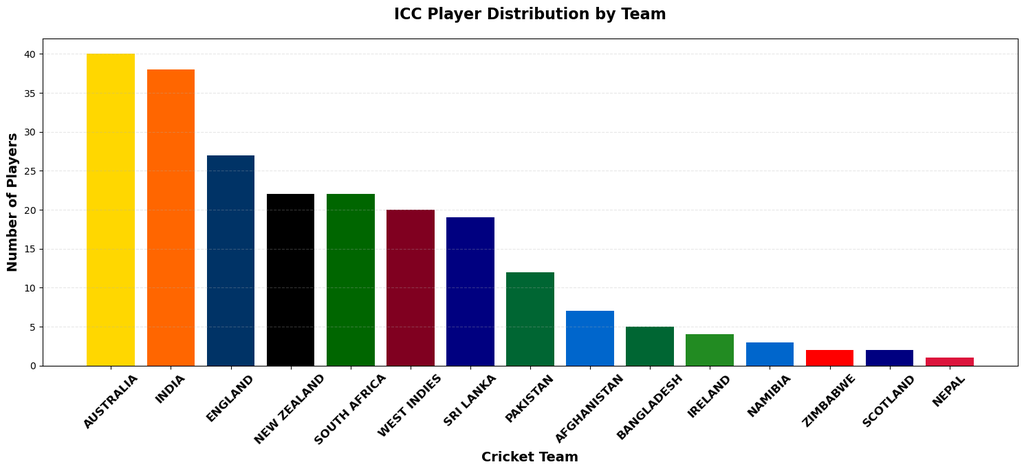

```python
plt.figure(figsize=(15,6))
colours=['#FFD700','#FF6600','#003366','#000000','#006600','#800020','#000080','#006633','#0066CC','#006633','#228B22',"#0066CC",'#FF0000','#000080','#DC143C']
plt.bar(list(df["Team"].value_counts().keys()),list(df["Team"].value_counts().values),color=colours)
plt.title('ICC Player Distribution by Team',
          fontsize=16, fontweight='bold', pad=20)
plt.xlabel('Cricket Team', fontsize=14, fontweight='bold')
plt.ylabel('Number of Players', fontsize=14, fontweight='bold')
plt.grid(axis='y', alpha=0.3, linestyle='--')
plt.tight_layout()
plt.xticks(rotation=45, fontsize=12, fontweight='bold')

plt.show()
```

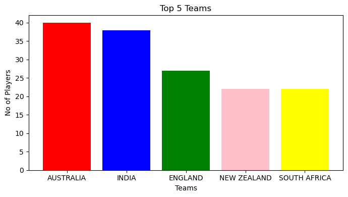

```python
plt.figure(figsize=(7,4))
plt.bar(list(df["Team"].value_counts()[0:5].keys()),list(df["Team"].value_counts()[0:5]),color=["r","b","g","pink","yellow"])
plt.title("Top 5 Teams")
plt.ylabel("No of Players")
plt.xlabel("Teams")
plt.tight_layout()
plt.show()
```

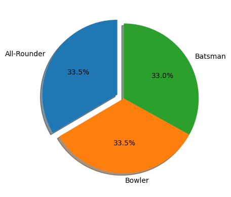

```python
plt.pie(list(df["Role"].value_counts()),labels=list(df["Role"].value_counts().keys()),autopct="%0.1f%%",startangle=90,shadow=True,explode=(0.1,0,0))
plt.show()
```

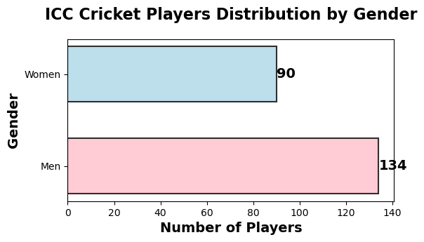

```python
plt.figure(figsize=(6, 3))
genders = list(df["Gender"].value_counts().keys())
counts = list(df["Gender"].value_counts().values)
colors =['pink','lightblue']
bars = plt.barh(genders, counts,
                color=colors,
                alpha=0.8,
                edgecolor='black',
                linewidth=1.5,
                height=0.6)
plt.title('ICC Cricket Players Distribution by Gender',
          fontsize=16, fontweight='bold', pad=20)
plt.xlabel('Number of Players', fontsize=14, fontweight='bold')
plt.ylabel('Gender', fontsize=14, fontweight='bold')
# Add value labels on bars
for bar, count in zip(bars, counts):
    plt.text(bar.get_width() + 0.1,
             bar.get_y() + bar.get_height()/2,
             str(count),
             ha='left', va='center',
             fontsize=14, fontweight='bold')
```

[figure not shown]

```python
plt.style.use('default')
sns.set_palette("husl")

# Create figure with subplots
fig = plt.figure(figsize=(20, 15))

# 1. Heatmap of the pivot table
plt.subplot(2, 3, 1)
pivot_data = df.pivot_table(index=['Format', 'Role'], columns='Gender',
                           values='Rating', aggfunc=['mean',"min","max","count"], fill_value=0)
sns.heatmap(pivot_data.corr(), annot=True, center=pivot_data.mean().mean(),
            fmt='.2f', cbar_kws={'label': 'Average Rating'})
plt.title('Average Ratings Heatmap\n(Format-Role vs Gender)', fontsize=12, fontweight='bold')
plt.ylabel('Format - Role')
plt.xlabel('Gender')
plt.tight_layout()
```

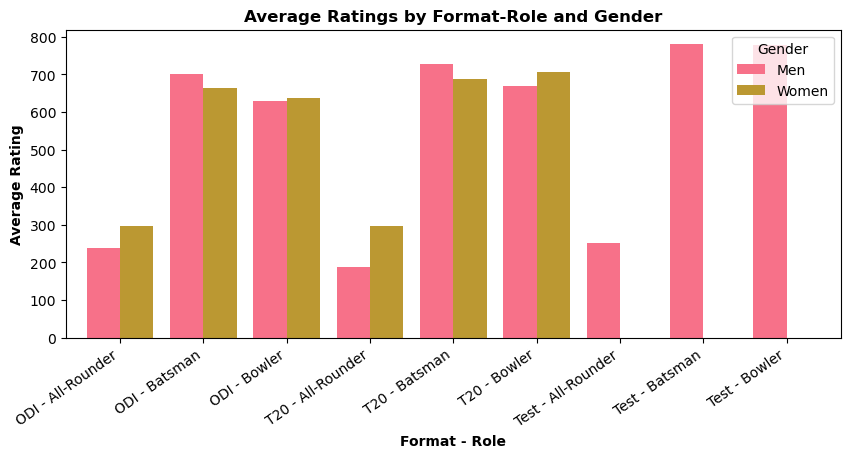

```python
plt.figure(figsize=(10,4))
grouped_data = df.groupby(['Format', 'Role', 'Gender'])['Rating'].mean().reset_index()
grouped_data['Format_Role'] = grouped_data['Format'] + ' - ' + grouped_data['Role']
bar_data = grouped_data.pivot(index='Format_Role', columns='Gender', values='Rating')
bar_data.plot(kind='bar', ax=plt.gca(), width=0.8,)
plt.title('Average Ratings by Format-Role and Gender', fontsize=12, fontweight='bold')
plt.xlabel('Format - Role',fontweight="bold")
plt.ylabel('Average Rating',fontweight="bold")
plt.legend(title='Gender', loc='upper right')
plt.xticks(rotation=35, ha='right')
plt.show()
```

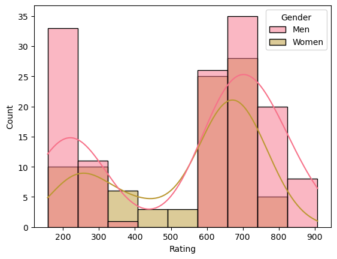

```python
sns.histplot(data=df,x="Rating",kde=True,hue="Gender")
plt.show()
```

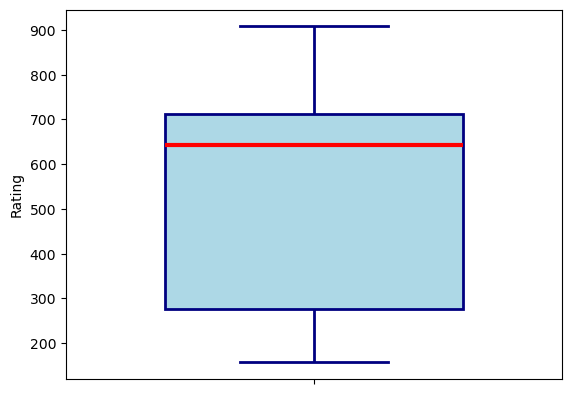

```python
sns.boxplot(data=df, y="Rating",
                       color='lightblue', width=0.6,
                       boxprops=dict(facecolor='lightblue', edgecolor='navy', linewidth=2),
                       whiskerprops=dict(color='navy', linewidth=2),
                       capprops=dict(color='navy', linewidth=2),
                       medianprops=dict(color='red', linewidth=3),
                       flierprops=dict(marker='o', markerfacecolor='red',
                                     markeredgecolor='darkred', markersize=6))
plt.show()
```

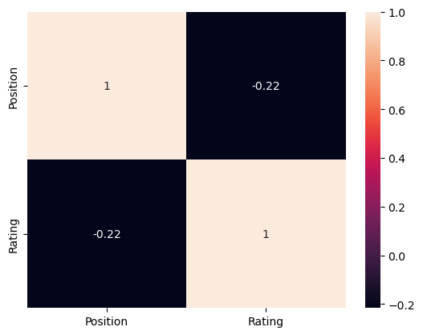

```python
sns.heatmap(df[["Position","Rating"]].corr(),annot=True)
```

## The project successfully demonstrates a complete data workflow from web scraping and data cleaning to in-depth analysis and visualization, providing a clear and comprehensive summary of the ICC cricket player rankings.